# Language Popularity Analysis

Adam

09 March, 23

This R Markdown file is for my analyses of Stack Overflow data. I used this data to find the most popular programming languages, and the popularity of R tags over time.

## Popularity of Programming Languages

This analysis showed me that the R language has steadily been becoming more popular since 2008, and now is even more popular than c++. c# has fallen from by far the most popular language in 2008 to the sixth most popular language in 2018. Python has rapidly grew in this period of time to rival JavaScript for the most popular language by Stack Overflow tags.

### Popularity of Programming Languages in 2018

I maniplulated the data to firstly calculate the proportion of tags, rather than the total number as I felt this was more meaningful. Next, I found the 9 most popular tags, and then added ‘R’ as a tenth tag. I then filtered for the year 2018, and plotted this as a bar chart, ordering it by the most to least popular.

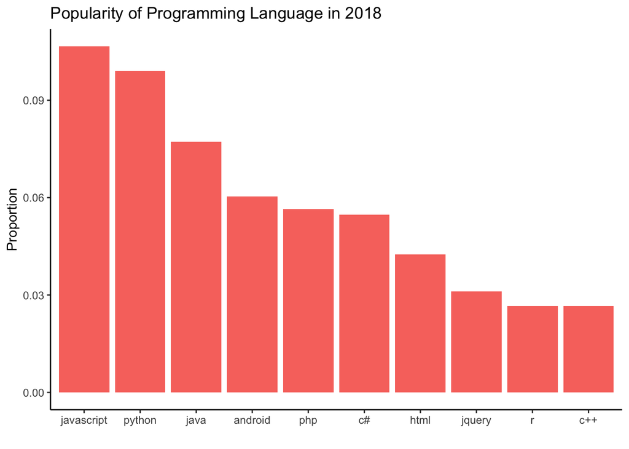

### Popularity of Programming Langauges Over Time

For the second chart, I plotted a line chart of the most popular tags over a period of time, to show which languages are becoming more and less popular.

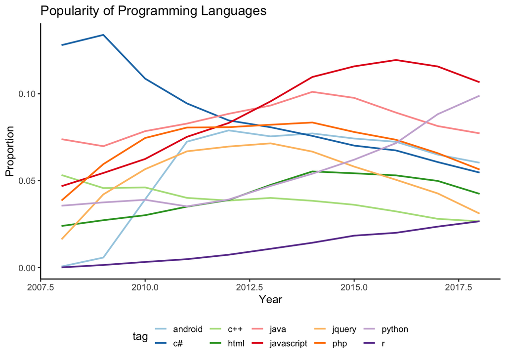

### Code

#### *Code for data manipulation:*

```r
#Finding Data as a Fraction
by_tag_year_fraction <- by_tag_year %>%
  mutate(fraction = number / year_total)

#Finding Most Popular Tags & R
sorted_tags <- by_tag_year %>%
  group_by(tag) %>%
  summarize(tag_total = sum(number)) %>%
  arrange(desc(tag_total))

highest_tags <- c(head(sorted_tags$tag, 9), 'r')

by_tag_subset <- by_tag_year_fraction %>%
  filter(tag %in% highest_tags)

#Data for 2018
year2018 <- by_tag_subset %>%
  filter(year == 2018) %>%
  select(tag, fraction) %>%
  arrange(fraction)
```

#### *Code for plot 1:*

```r
ggplot(year2018, aes(fct_reorder(tag, fraction, .desc = TRUE), fraction, fill = 'Navy')) +
  geom_col() +
  theme_classic() +
  theme(legend.position="none") +
  labs(title = 'Popularity of Programming Language in 2018',
       x ='',
       y = 'Proportion')
```

#### *Code for plot 2:

```r
ggplot(by_tag_subset, aes(year, fraction, color=tag)) +
  geom_line(size = 0.8) +
  theme_classic() +
  labs(title = 'Popularity of Programming Languages',
       x = 'Year',
       y = 'Proportion') +
  theme(legend.key.size = unit(0.5, 'cm'),legend.position = 'bottom') +
  scale_color_brewer(palette="Paired")
```

## Popularity of R Related Tags

This was a seperate project, but related to I added it to this report. I found that ‘ggplot2’ and ‘dplyr’ are the most popular tags, which increased however recently started to sharply decrease, which is similar with the rest of the tags. Note, I did not include the ‘R’ tag in the first analysis.

### Popularity of R Tags

In this analysis the bulk of the code is using dplyr to sort and filter data, and also join tables together. This allowed me to get the data I needed, and I then plotted a faceted graph of the 9 most popular R related tags. The data for this analysis is different than the other 3, as rather than just the number of times each tag is mentioned. I specifically found the number of times it is mentioned in questions and answers, and plotted each separately. Interestingly, with most tags, they have been used more in answers than questions.

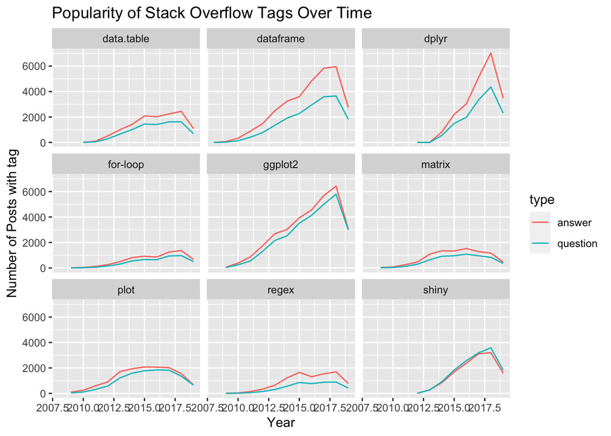

### Popularity of ‘R’, ‘dplyr’ and ‘ggplot2’ Over Time

In this analysis, I plotted 3 R related tags, and the proportion of times they are mentioned in Stack Overflow.

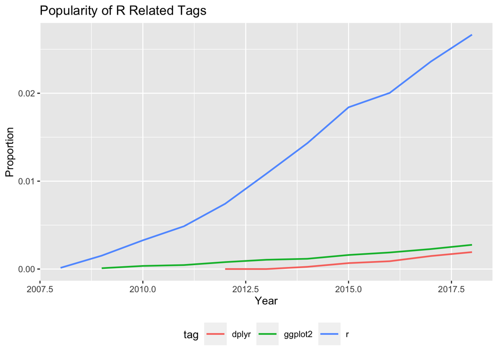

### Code

#### *Code for data manipulation:*

```r
#Joining tables
question_data <- questions %>%
  left_join(question_tags, by = c("id" = "question_id")) %>%
  left_join(tags, by = c("tag_id" = "id")) %>%
  replace_na(list(tag_name='only-r'))

#Grouping Data and Arranging
question_data %>%
  group_by(tag_name) %>%
  summarize(score = mean(score),
            num_questions = n()) %>%
  arrange(desc(num_questions))

#Data manipulation
answer_counts <- answers %>%
  count(question_id) %>%
  arrange(desc(n))

question_answer_counts <- questions %>%
  left_join(answer_counts, by = c('id' = 'question_id')) %>%
  replace_na(list(n=0))

tagged_answers <- question_answer_counts %>%
  inner_join(question_tags, by = c('id' = 'question_id')) %>%
  inner_join(tags, by = c('tag_id' = 'id'))


tagged_answers %>%
  # Aggregate by tag_name
  group_by(tag_name)  %>%
  # Summarize questions and average_answers
  summarize(questions = n(),
            average_answers = mean(n)) %>%
  # Sort the questions in descending order
  arrange(desc(questions))


# Inner join the question_tags and tags tables with the questions table
questions_with_tags <- questions %>%
  inner_join(question_tags, by = c('id' = 'question_id')) %>%
  inner_join(tags, by = c('tag_id' = 'id'))

# Inner join the question_tags and tags tables with the answers table
answers_with_tags <- answers %>%
  inner_join(question_tags, by = c('question_id' = 'question_id')) %>%
  inner_join(tags, by = c('tag_id' = 'id'))


posts_with_tags <- bind_rows(questions_with_tags %>% mutate(type = "question"),
                             answers_with_tags %>% mutate(type = "answer"))

by_year <- posts_with_tags %>%
  mutate(year = year(creation_date)) %>%
  count(type, year, tag_name)

by_year_filtered_extend <- by_year %>%
  filter(tag_name %in% c('dplyr', 'ggplot2', 'dataframe', 'shiny', 'data.table',
                         'plot', 'regex', 'matrix', 'for-loop'))
```

#### *Code for plot 1:*

```r
ggplot(by_year_filtered_extend, aes(year,  n, color = type)) +
  geom_line() +
  facet_wrap(~ tag_name) +
  ggtitle('Popularity of Stack Overflow Tags Over Time') +
  labs(x='Year', y='Number of Posts with tag')
```

#### *Code for plot 2:*

```r
r_tags_over_time <- by_tag_year_fraction %>%
  filter(tag %in% c('r', 'dplyr', 'ggplot2'))

ggplot(r_tags_over_time, aes(year, fraction, color = tag)) +
  geom_line(size = 0.8) +
  labs(title = 'Popularity of R Related Tags',
       x = 'Year',
       y = 'Proportion') +
  theme(legend.key.size = unit(0.8, 'cm'),legend.position = 'bottom')
```